# Patterns in My Daily Drink Purchases

## What This Data Shows

This visual data story is based on my Project 4 observational logging data. I used a Google Form to record 20 drink purchase observations. Each row records one drink purchase, including drink type, cost, purchase place, and the time when the response was entered into the form.

## What Drinks I Bought Most Often

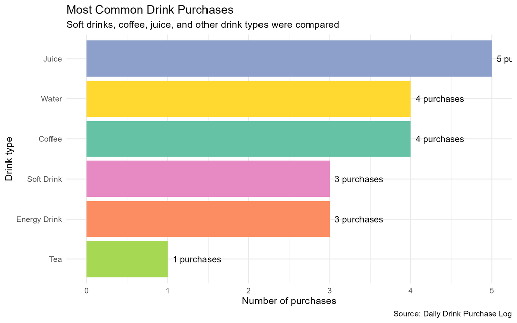

Bar chart showing the number of purchases for each drink type. Juice was the most common drink, followed by water and coffee.

This chart shows the types of drinks I recorded in my Project 4 data. Juice appeared the most, with 5 purchases. Water and coffee were also common, with 4 purchases each. Tea was only recorded once.

From this chart, I can see that my drink purchases were quite mixed. I did not only buy one type of drink, but juice, water, and coffee were the main ones in this set of observations.

## Where Drinks Cost More

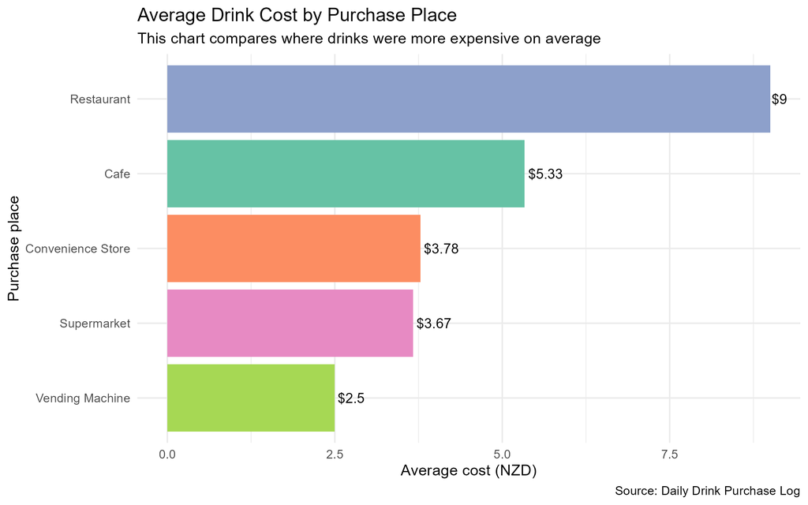

Bar chart showing the average cost of drinks by purchase place. Restaurant had the highest average cost, while vending machine had the lowest average cost.

This chart compares the average cost of drinks from different places. Restaurant had the highest average cost, at $9.00. Cafe was also quite high, with an average cost of $5.33. Vending machine had the lowest average cost, at $2.50.

This shows that where I bought the drink made a difference to the price. Drinks from restaurants and cafes were more expensive, while vending machines and supermarkets were cheaper. Since this is only a small set of data, I would not say this is true for everyone, but it does show a pattern in my own observations.

## How the Observations Were Entered Into the Form

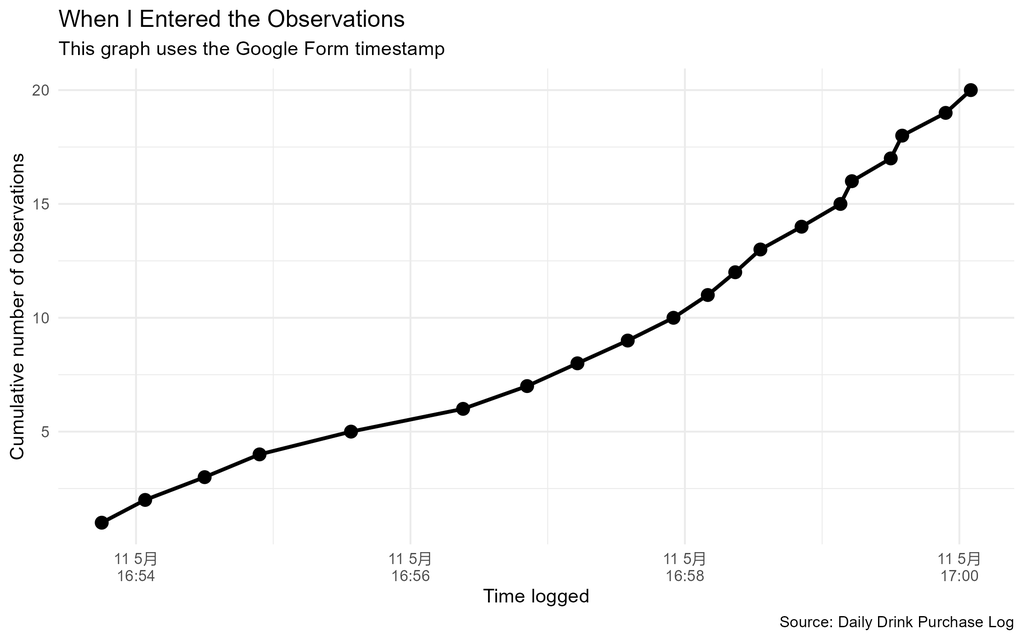

Line chart showing the cumulative number of Project 4 observations entered into the Google Form over time.

This chart uses the Google Form timestamp to show when the observations were entered into the dataset. The line increases from 1 to 20 as more responses were added to the form.

This visualisation shows the data logging process rather than the actual time when each drink was purchased. Since the observations were entered within a short period, this chart should not be used to explain drink-buying behaviour across the day. Instead, it helps show that 20 Project 4 observations were recorded as separate entries.